# Fundamentals of Computing and Data Display

## Google Trends + ACS

Now lets add another data set. The censusapi package provides a nice R interface for communicating with this API. However, before running queries we need an access key. This (easy) process can be completed here:

https://api.census.gov/data/key_signup.html

Once you have an access key, store this key in the cs_key object. We will use this object in all following API queries.

```r
cs_key <- "your key"
```

In the following, we request basic socio-demographic information (population, median age, median household income, income per capita) for cities and villages in the state of Illinois.

```r
acs_il <- getCensus(name = "acs/acs5",
                    vintage = 2016,
                    vars = c("NAME", "B01001_001E", "B06002_001E", "B19013_001E", "B19301_001E"),
                    region = "place:*",
                    regionin = "state:17",
                    key = cs_key)
head(acs_il)
```

|  | state | place | NAME | B01001_001E | B06002_001E | B19013_001E | B19301_001E |
| --- | --- | --- | --- | --- | --- | --- | --- |
| 1 | 17 | 11202 | Carlinville city, Illinois | 5297 | 36.7 | 40250 | 22441 |
| 2 | 17 | 21410 | Eagarville village, Illinois | 165 | 39.2 | 48750 | 31400 |
| 3 | 17 | 57043 | Owaneco village, Illinois | 201 | 44.6 | 42500 | 22708 |
| 4 | 17 | 34137 | Henning village, Illinois | 243 | 31.9 | 55500 | 18009 |
| 5 | 17 | 00880 | Allerton village, Illinois | 288 | 42.6 | 58125 | 24356 |
| 6 | 17 | 57693 | Parkersburg village, Illinois | 146 | 41.1 | 48000 | 24795 |

Convert values that represent missings to NAs.

```r
acs_il[acs_il == -666666666] <- NA
```

Now, it might be useful to rename the socio-demographic variables (`B01001_001E` etc.) in our data set and assign more meaningful names.

```r
acs_il <-
  acs_il %>%
  rename(pop = B01001_001E, age = B06002_001E, hh_income = B19013_001E, income = B19301_001E)
```

Print the first rows of the variable `NAME`.

```r
head(acs_il$NAME)
```

```
[1] "Carlinville city, Illinois"
[2] "Eagarville village, Illinois"
[3] "Owaneco village, Illinois"
[4] "Henning village, Illinois"
[5] "Allerton village, Illinois"
[6] "Parkersburg village, Illinois"
```

It seems like we could try to use this location information listed above to merge this data set with the Google Trends data. However, we first have to clean `NAME` so that it has the same structure as `location` in the search interest by city data. Add a new variable `location` to the ACS data that only includes city names.

| state | place | location | NAME | pop | age | hh_income | income |
| --- | --- | --- | --- | --- | --- | --- | --- |
| 17 | 11202 | Carlinville | city | 5297 | 36.7 | 40250 | 22441 |
| 17 | 21410 | Eagarville | village | 165 | 39.2 | 48750 | 31400 |
| 17 | 57043 | Owaneco | village | 201 | 44.6 | 42500 | 22708 |
| 17 | 34137 | Henning | village | 243 | 31.9 | 55500 | 18009 |
| 17 | 00880 | Allerton | village | 288 | 42.6 | 58125 | 24356 |
| 17 | 57693 | Parkersburg | village | 146 | 41.1 | 48000 | 24795 |
| 17 | 04689 | Belgium | village | 408 | 43.0 | 34375 | 19379 |
| 17 | 62744 | Rankin | village | 457 | 42.3 | 44688 | 23717 |
| 17 | 75783 | Toulon | city | 1388 | 46.2 | 44783 | 22344 |
| 17 | 22398 | Eddyville | village | 73 | 37.8 | 17500 | 13864 |

[output cut: 990 more lines]

| location | geo | gprop | crime | loans | state | place | NAME | pop | age | hh_income | income |
| --- | --- | --- | --- | --- | --- | --- | --- | --- | --- | --- | --- |
| Riverwoods | US-IL | web | 100 | NA | 17 | 64538 | village | 3759 | 48.3 | 187857 | 77562 |
| Braidwood | US-IL | web | 50 | 45 | 17 | 07770 | city | 6102 | 44.2 | 61074 | 30101 |
| Macomb | US-IL | web | 32 | NA | 17 | 45889 | city | 18771 | 24.2 | 35459 | 19862 |
| Dunlap | US-IL | web | 29 | NA | 17 | 21176 | village | 1351 | 34.4 | 101667 | 38228 |
| Riverdale | US-IL | web | 28 | 72 | 17 | 64278 | village | 13047 | 35.0 | 31438 | 18706 |
| Freeport | US-IL | web | 25 | NA | 17 | 27884 | city | 24784 | 42.7 | 35552 | 21853 |

Now we can utilize information from both data sources. As an example, print the `crime` and `loans` search popularity for the first ten cities in Illinois with the highest population (in 2016).

| location | geo | gprop | crime | loans | state | place | NAME | pop | age | hh_income | income |
| --- | --- | --- | --- | --- | --- | --- | --- | --- | --- | --- | --- |
| Rockford | US-IL | web | 23 | NA | 17 | 65000 | city | 149597 | 36.0 | 40143 | 22608 |
| Evanston | US-IL | web | 22 | NA | 17 | 24582 | city | 75472 | 35.3 | 71317 | 43945 |
| Quincy | US-IL | web | 10 | 31 | 17 | 62367 | city | 40689 | 39.9 | 42078 | 25152 |
| Lansing | US-IL | web | 23 | NA | 17 | 42028 | village | 28369 | 40.9 | 50107 | 25025 |
| Alton | US-IL | web | NA | 40 | 17 | 01114 | city | 27175 | 37.5 | 37108 | 21189 |
| Harvey | US-IL | web | 23 | NA | 17 | 33383 | city | 25625 | 35.4 | 21909 | 13715 |
| Freeport | US-IL | web | 25 | NA | 17 | 27884 | city | 24784 | 42.7 | 35552 | 21853 |
| Zion | US-IL | web | 21 | 86 | 17 | 84220 | city | 24195 | 32.7 | 46735 | 19814 |
| Maywood | US-IL | web | NA | 42 | 17 | 47774 | village | 24029 | 33.6 | 44126 | 17982 |
| Dolton | US-IL | web | NA | 32 | 17 | 20292 | village | 23113 | 36.2 | 44511 | 19816 |

| hh_income_level | mean_loans |
| --- | --- |
| Above hh income | 36.57143 |
| Below hh income | 48.24324 |

Is there a relationship between the median household income and the search popularity of `loans`? Plot a scatterplot with `qplot()`.

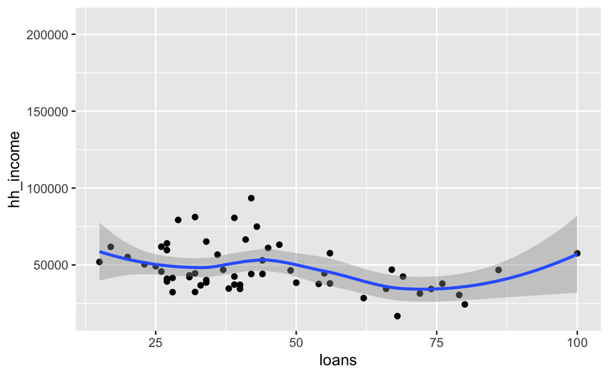